# Study of How Sleep and Waking Times Affect Sleep Quality

## Introduction

Sleep is an important part of health, concentration, and overall wellbeing. How I feel after waking up from a night’s sleep greatly affects my day so I wanted to analyse my own sleep to look for any trends to see if I could improve my own sleeping habits to better my sleep and in turn improve the quality of my day. For this project, I collected observational sleep data using a Google Form over multiple days. The data included the number of hours slept, what times I slept, what times I woke up, what day of the week it was and how I rated the quality of the sleep.

This visual story explores how my sleeping habits might have influenced my sleep quality and also how my sleep patterns vary throughout the week.

## Sleep Duration and Sleep Quality

It’s a common conception that getting more sleep improves how rested one may feel the next day. This visualization explores the relationship between the number of hours slept and sleep quality ratings.

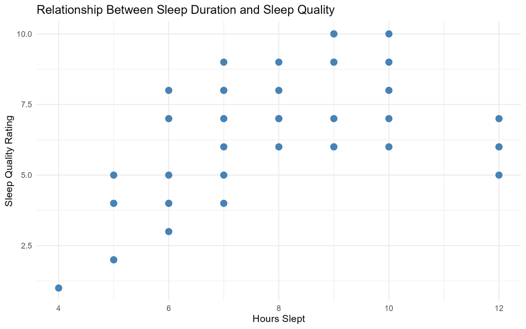

The scatterplot suggests a positive relationship between sleep duration and sleep quality. Observations with lower sleep durations often have lower quality ratings, while longer sleep durations tend to correspond with higher ratings. This trend seems to verify my own feelings as sleeping about 7-10 hours which is very similar to the amount of sleep generally recommended to most adults resulted in the higher ratings of sleep quality.

## Average Sleep Quality Across the Week

Sleep quality can vary depending on the day of the week due to study schedules, workload, routines, and weekend habits.

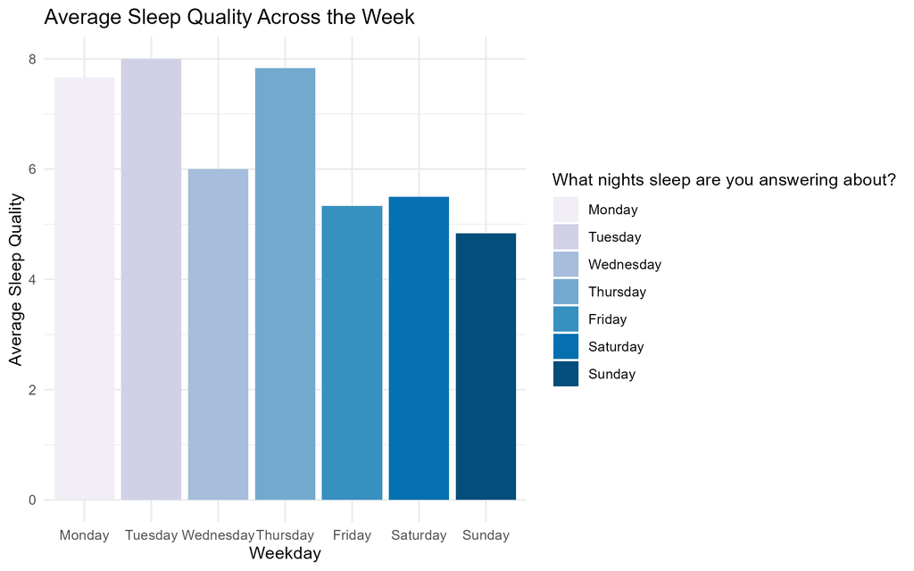

This visualization compares average sleep quality across different weekdays. Some weekdays show noticeably higher average sleep quality than others, suggesting that routines and responsibilities may influence sleeping experiences throughout the week. The Friday, Saturday and Sunday data checks out with my own conception of my routines during the weekend such as staying up late to watch football matches, hangout with friends, play video games into the early morning and reading a lot in bed. All of which generally resulted in me sleeping in the early morning and waking up later in the day which seemed to result in a lower quality sleep.

## Sleep Quality and Wake-Up Times

Wake-up times may also affect how rested people feel throughout the day.

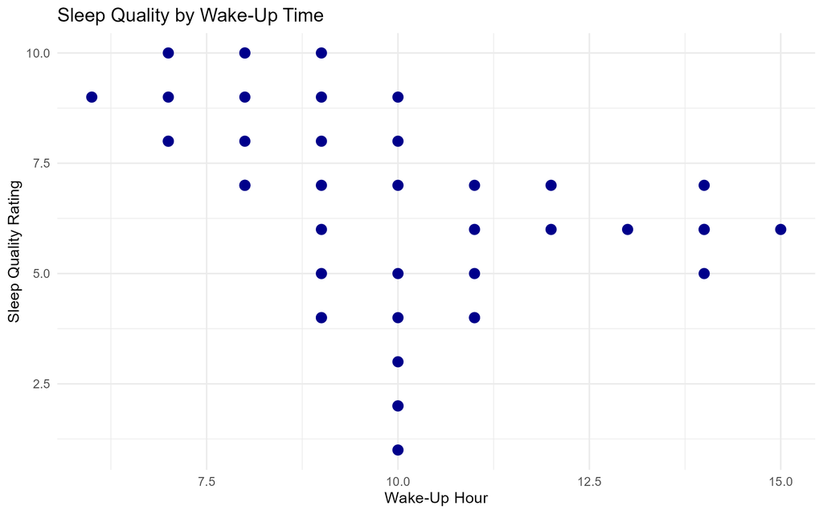

This visualization explores whether later wake-up times are associated with better sleep quality. Although the relationship has some outliers, generally it seems that the earlier I wake up, the more well-rested I would be and also would feel like I had a higher quality sleep. This again check out to my expectations as I definitely did find that waking up earlier in the day resulted in me feeling much more refreshed than if I had woken up in the afternoon.

## Conclusion

Overall, the visualizations suggest that both sleep duration and sleeping schedules can influence perceived sleep quality. The data demonstrates how my sleeping habits vary throughout the week and highlights patterns that may affect wellbeing and daily performance.